# Visualize data with the matplotlib library

## 3D Plots

To use 3D graphics in matplotlib, create an instance of the `Axes3D` class. You can add 3D axes to a matplotlib figure canvas in the same way as you add 2D axes; or, more conveniently, by passing a `projection='3d'` argument to the `add_axes` or `add_subplot` functions.

You must import the `Axes3D` class:

```
from mpl_toolkits.mplot3d.axes3d import Axes3D
```

You can create these types of 3D plots:

- 3D surface plot
- 3D wireframe plot
- 3D contour plot

### 3D surface plot

You create a surface with the `plot_surface()` function. You can customize the stride (the space between each contour line extension), the linewidth of that line, and many more properties with the appropriate function parameters.

By default, a surface will be colored in shades of a solid color, but it also supports color mapping by supplying the `cmap` argument. Some arguments are `coolwarm` and `hot`.

Here's a list of the most common arguments for 3D surface plots:

```
X, Y, Z      Data values as 2D arrays
rstride      Array row stride (step size), defaults to 10
cstride      Array column stride (step size), defaults to 10
color        Color of the surface patches
cmap         A colormap for the surface patches.
facecolors   Face colors for the individual patches
norm         An instance of Normalize to map values to colors
vmin         Minimum value to map
vmax         Maximum value to map
shade        Whether to shade the facecolors
```

The entire list of parameters is here: [mplot3d API](http://matplotlib.org/mpl_toolkits/mplot3d/api.html).

You can also use regular matplotlib parameters for axes, titles, colors, and so on.

Create two 3D surface subplots, one with color grading and a color bar.

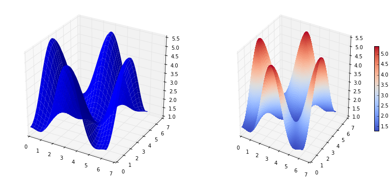

```python
import matplotlib.pyplot as plt
%matplotlib inline
import numpy as np
from mpl_toolkits.mplot3d.axes3d import Axes3D

fig = plt.figure(figsize=(14,6))

alpha = 0.7
phi_ext = 2 * np.pi * 0.5

def flux_qubit_potential(phi_m, phi_p):
    return 2 + alpha - 2 * np.cos(phi_p)*np.cos(phi_m) - alpha * np.cos(phi_ext - 2*phi_p)
phi_m = np.linspace(0, 2*np.pi, 100)
phi_p = np.linspace(0, 2*np.pi, 100)
X,Y = np.meshgrid(phi_p, phi_m)
Z = flux_qubit_potential(X, Y).T

# `ax` is a 3D-aware axis instance because of the
# projection='3d' keyword argument to add_subplot
ax = fig.add_subplot(1, 2, 1, projection='3d')

p = ax.plot_surface(X, Y, Z, rstride=3, cstride=4, linewidth=0)

# surface_plot with color grading and color bar
ax = fig.add_subplot(1, 2, 2, projection='3d')
p = ax.plot_surface(X, Y, Z, rstride=1, cstride=1,
                    cmap=plt.cm.coolwarm, linewidth=0, antialiased=False)
cb = fig.colorbar(p, shrink=0.5)
```

### 3D wireframe

Use the `plot_wireframe()` function to create a wireframe surface.

These are the most common arguments for 3D wireframe plots:

```
X, Y, Z      Data values as 2D arrays
rstride      Array row stride (step size), defaults to 1
cstride      Array column stride (step size), defaults to 1
```

You can also use regular matplotlib parameters for axes, titles, colors, and so on.

Create a 3D wireframe plot.

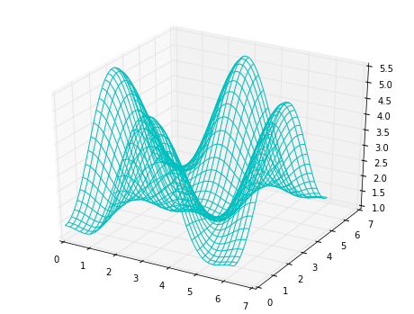

```python
import matplotlib.pyplot as plt
%matplotlib inline
import numpy as np
from mpl_toolkits.mplot3d.axes3d import Axes3D

alpha = 0.7
phi_ext = 2 * np.pi * 0.5

def flux_qubit_potential(phi_m, phi_p):
    return 2 + alpha - 2 * np.cos(phi_p)*np.cos(phi_m) - alpha * np.cos(phi_ext - 2*phi_p)
phi_m = np.linspace(0, 2*np.pi, 100)
phi_p = np.linspace(0, 2*np.pi, 100)
X,Y = np.meshgrid(phi_p, phi_m)
Z = flux_qubit_potential(X, Y).T

fig = plt.figure(figsize=(8,6))
ax = fig.add_subplot(1, 1, 1, projection='3d')

p = ax.plot_wireframe(X, Y, Z, rstride=3, cstride=3, color='c')
```

### 3D contour plot

Add the `contourf()` function to an axis to have a projection of the 3D graph on the specified axis.

Create a 3D surface plot with color mapping and a contour on the Z axis.

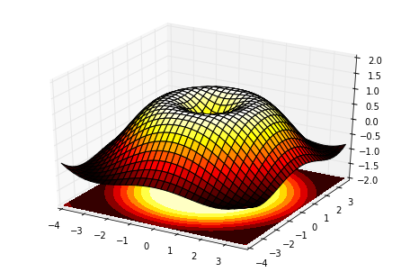

```python
import matplotlib.pyplot as plt
%matplotlib inline
import numpy as np
from mpl_toolkits.mplot3d.axes3d import Axes3D

fig = plt.figure()
ax = Axes3D(fig)
X = np.arange(-4,4,0.25)
Y = np.arange(-4,4,0.25)
X, Y = np.meshgrid(X, Y)
R = np.sqrt( X**2 + Y **2)
Z = np.sin(R)
ax.plot_surface(X, Y, Z, rstride=1, cstride=1, cmap = plt.cm.hot)
ax.contourf(X, Y, Z , zdir='z', offset= -2, cmap=plt.cm.hot)
ax.set_zlim(-2,2)
plt.show()
```

## Resources

- [matplotlib documentation](http://matplotlib.org/)
- [matplotlib examples](http://matplotlib.org/examples/index.html)
- [NumPy](http://www.numpy.org/)
- [MathWorks ColorSpec](http://www.mathworks.com/help/matlab/ref/colorspec.html)
- [LineSpec property](http://www.mathworks.com/help/matlab/ref/linespec.html)
- [STIX fonts](http://www.stixfonts.org/)
- [mplot3d API](http://matplotlib.org/mpl_toolkits/mplot3d/api.html)

## Author

Inge Halilovic is a content strategist for the Data Science Experience. She adapted this notebook from one that was originally published for [Data Scientist Workbench](https://datascientistworkbench.com/).

## Data citations

This notebook uses some examples that are derived from the following sources:

- matplotlib.org
- Lecture 4 in [Lectures on scientific computing with Python](https://github.com/jrjohansson/scientific-python-lectures/blob/12c2d6976230ad3e604153e2b40b3282fa168c86/README.md) by J.R. Johansson: http://jrjohansson.github.io/.

Copyright © Big Data University 2017. This notebook and its source code are released under the terms of the MIT License.